# Regression models course project: Motor cars trend

Abdul Rasheed Narejo

12/09/2018

## Objective of the assignment

You work for Motor Trend, a magazine about the automobile industry. Looking at a data set of a collection of cars, they are interested in exploring the relationship between a set of variables and miles per gallon (MPG) (outcome).

This report examines the relationship between mileage (mpg or miles per gallon) and transmission (am) type of the car. We have to check whether;

- an automatic or manual transmission is better for MPG and,
- quantify the MPG difference between automatic and manual transmissions

## About the data

The data was extracted from the 1974 Motor Trend US magazine, and comprises fuel consumption and 10 aspects of automobile design and performance for 32 automobiles (1973–74 models). The data frame has 32 observations on 11 (numeric) variables. the variable description is provided below.

- **mpg** Miles/(US) gallon
- **cy** Number of cylinders
- **disp** Displacement (cu.in.)
- **hp** Gross horsepower
- **drat** Rear axle ratio
- **wt** Weight (1000 lbs)
- **qsec** 1/4 mile time
- **vs** Engine (0 = V-shaped, 1 = straight)
- **am** Transmission (0 = automatic, 1 = manual)
- **gear** Number of forward gears
- **carb** Number of carburetors

load libraries

```r
library(ggplot2) # for visualization
```

## loading the data

```r
data(mtcars)
str(mtcars)
```

```
## 'data.frame':    32 obs. of  11 variables:
##  $ mpg : num  21 21 22.8 21.4 18.7 18.1 14.3 24.4 22.8 19.2 ...
##  $ cyl : num  6 6 4 6 8 6 8 4 4 6 ...
##  $ disp: num  160 160 108 258 360 ...
##  $ hp  : num  110 110 93 110 175 105 245 62 95 123 ...
##  $ drat: num  3.9 3.9 3.85 3.08 3.15 2.76 3.21 3.69 3.92 3.92 ...
##  $ wt  : num  2.62 2.88 2.32 3.21 3.44 ...
##  $ qsec: num  16.5 17 18.6 19.4 17 ...
##  $ vs  : num  0 0 1 1 0 1 0 1 1 1 ...
##  $ am  : num  1 1 1 0 0 0 0 0 0 0 ...
##  $ gear: num  4 4 4 3 3 3 3 4 4 4 ...
##  $ carb: num  4 4 1 1 2 1 4 2 2 4 ...
```

## Data processing

According to the data description, “am” column represents car transmission system with 0 being automatic and 1 being manual transmission. “cyl”, “vs”, “gear”, and “carbs” also converted into factor variables.

```r
mtcars$cyl <- factor(mtcars$cyl)
mtcars$vs <- factor(mtcars$vs)
mtcars$am <- factor(mtcars$am, labels =c("Automatic", "Manual"))
mtcars$gear <- factor(mtcars$gear)
mtcars$carb <- factor(mtcars$carb)
```

## Exploratory data analysis

Let’s graphically project mpg (mileage) for different am (transmission) types.

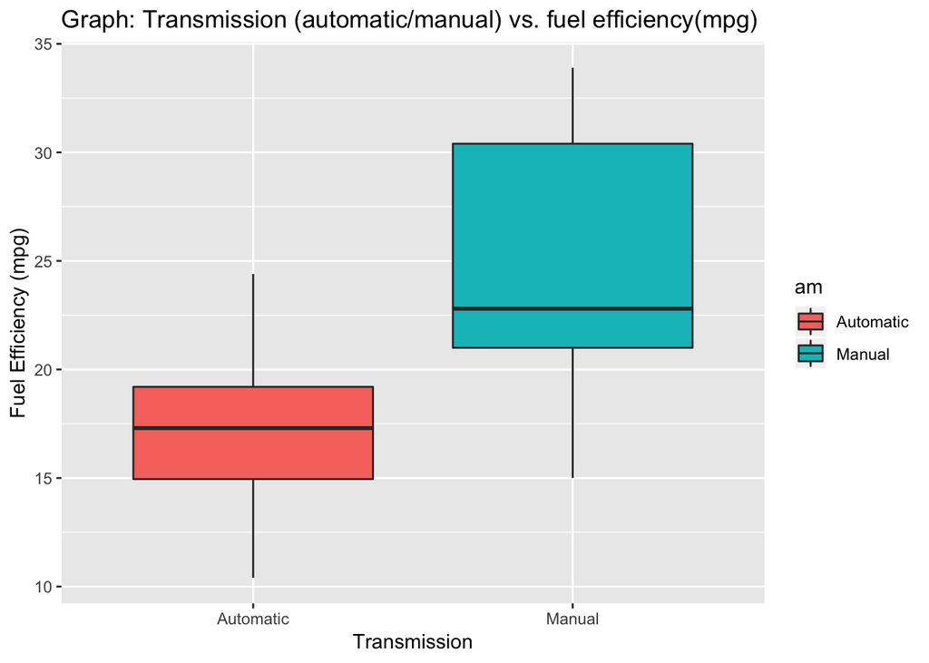

```r
ggplot(mtcars, aes(x = am, y = mpg, fill=am) ) +
    geom_boxplot() +
    ggtitle("Graph: Transmission (automatic/manual) vs. fuel efficiency(mpg) ") +
    xlab("Transmission") +
    ylab("Fuel Efficiency (mpg)")
```

Manual cars generally have better mileage vs. automatic cars. Let’s check if the difference is statistically significant.

## Statistical Inference

To check whether cars mileage (mpg) is impacted by transmission type (am), we will set a null and alternative hypothesis;  
**H0:** mpg of manual and automatic cars are no different.  
**H1:** there is significant difference between mpg manual vs automatic cars.

We use t-test to verify this.

```r
test <- t.test(mpg ~ am, data = mtcars)

test$p.value
```

```
## [1] 0.001373638
```

Based on p.value of 0.00137, which is significantly less than 0.05, we reject null hyothesis. There is significant difference in mpg of two types of cars.

# Simple linear regression model

We will use mpg as dependent variable and am as independent variable to fit simple linear regression model.

```r
baseModel <- lm(mpg ~ am, data = mtcars)
summary(baseModel)
```

```
##
## Call:
## lm(formula = mpg ~ am, data = mtcars)
##
## Residuals:
##     Min      1Q  Median      3Q     Max
## -9.3923 -3.0923 -0.2974  3.2439  9.5077
##
## Coefficients:
##             Estimate Std. Error t value Pr(>|t|)
## (Intercept)   17.147      1.125  15.247 1.13e-15 ***
## amManual       7.245      1.764   4.106 0.000285 ***
## ---
## Signif. codes:  0 '***' 0.001 '**' 0.01 '*' 0.05 '.' 0.1 ' ' 1
##
## Residual standard error: 4.902 on 30 degrees of freedom
## Multiple R-squared:  0.3598, Adjusted R-squared:  0.3385
## F-statistic: 16.86 on 1 and 30 DF,  p-value: 0.000285
```

The adjusted R squared is 0.3385 which means that only 33.85% of variance can be explained by the model.

Lets build a model that regresses mpg on all other variables in dataset to see if other variables can better explain the residual variance.

```r
fullModel <- lm(mpg ~ ., data = mtcars)
summary(fullModel)
```

```
##
## Call:
## lm(formula = mpg ~ ., data = mtcars)
##
## Residuals:
##     Min      1Q  Median      3Q     Max
## -3.5087 -1.3584 -0.0948  0.7745  4.6251
##
## Coefficients:
##             Estimate Std. Error t value Pr(>|t|)
## (Intercept) 23.87913   20.06582   1.190   0.2525
## cyl6        -2.64870    3.04089  -0.871   0.3975
## cyl8        -0.33616    7.15954  -0.047   0.9632
## disp         0.03555    0.03190   1.114   0.2827
## hp          -0.07051    0.03943  -1.788   0.0939 .
## drat         1.18283    2.48348   0.476   0.6407
## wt          -4.52978    2.53875  -1.784   0.0946 .
## qsec         0.36784    0.93540   0.393   0.6997
## vs1          1.93085    2.87126   0.672   0.5115
## amManual     1.21212    3.21355   0.377   0.7113
## gear4        1.11435    3.79952   0.293   0.7733
## gear5        2.52840    3.73636   0.677   0.5089
## carb2       -0.97935    2.31797  -0.423   0.6787
## carb3        2.99964    4.29355   0.699   0.4955
## carb4        1.09142    4.44962   0.245   0.8096
## carb6        4.47757    6.38406   0.701   0.4938
## carb8        7.25041    8.36057   0.867   0.3995
## ---
## Signif. codes:  0 '***' 0.001 '**' 0.01 '*' 0.05 '.' 0.1 ' ' 1
##
## Residual standard error: 2.833 on 15 degrees of freedom
## Multiple R-squared:  0.8931, Adjusted R-squared:  0.779
## F-statistic:  7.83 on 16 and 15 DF,  p-value: 0.000124
```

As expected, this model has R-squared of 0.8931. However, none of the cofficients are significant at 0.05 level.

We will use step function from R to check which variables to include in final model.

```r
stepModel <- step(fullModel, direction = "backward", trace = FALSE)
summary(stepModel)
```

```
##
## Call:
## lm(formula = mpg ~ cyl + hp + wt + am, data = mtcars)
##
## Residuals:
##     Min      1Q  Median      3Q     Max
## -3.9387 -1.2560 -0.4013  1.1253  5.0513
##
## Coefficients:
##             Estimate Std. Error t value Pr(>|t|)
## (Intercept) 33.70832    2.60489  12.940 7.73e-13 ***
## cyl6        -3.03134    1.40728  -2.154  0.04068 *
## cyl8        -2.16368    2.28425  -0.947  0.35225
## hp          -0.03211    0.01369  -2.345  0.02693 *
## wt          -2.49683    0.88559  -2.819  0.00908 **
## amManual     1.80921    1.39630   1.296  0.20646
## ---
## Signif. codes:  0 '***' 0.001 '**' 0.01 '*' 0.05 '.' 0.1 ' ' 1
##
## Residual standard error: 2.41 on 26 degrees of freedom
## Multiple R-squared:  0.8659, Adjusted R-squared:  0.8401
## F-statistic: 33.57 on 5 and 26 DF,  p-value: 1.506e-10
```

## Appendix

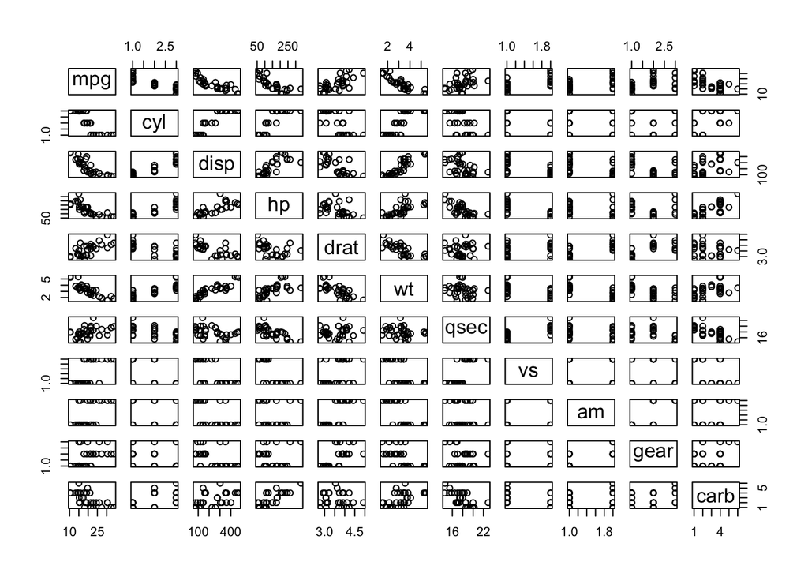

```r
# scatterplot matrix
pairs(mpg ~ ., data=mtcars)
```

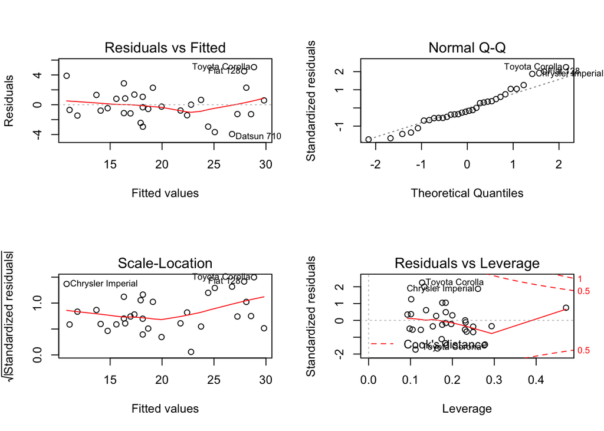

```r
# residual plots
par(mfrow = c(2, 2))
plot(stepModel)
```